# BaSiC

Wei Sun

2019-10-01

This R markdown file illustrate the usage of R package `basic` with application on the bulk sample and single cell sequencing data generated by Gawad, C., Koh, W., & Quake, S. R. (2014). *Dissecting the clonal origins of childhood acute lymphoblastic leukemia by single-cell genomics*. PNAS, 111(50), 17947-17952. This study collected bulk and single cell sequencing data from six childhood acute lymphoblastic leukemia (ALL) patients. This is a type of cancer with relatively small number of somatic mutations. Altogether 278 mutations are identified from 6 patients, with the number of mutations per patient varies from 10 to 105. After identifying somatic mutations from exome-seq of bulk samples, they sequenced 1,479 single tumor cells from these six patients using target sequencing with high depth.

BaSiC is designed to analyze exome-seq data with a relatively large number of mutations per sample. In addition, Basic exploit the read count information to impute mutation calls when sequence depth in single cells are relatively low. Since this dataset has relatively small number of mutations and high read-depth in single cells, it is not the type data that BaSiC is designed for. Neverthless, we apply BaSiC to demonstrate its performance in this dataset.

```r
library(basic)
library(gridExtra)
library(ggplot2)
library(ggcorrplot)
library(reshape2)
library(ggpubr)
```

We downloaded the information of somatic mutations of bulk tumor samples from [Supplementary Dataset_S01](https://www.pnas.org/highwire/filestream/617852/field_highwire_adjunct_files/1/pnas.1420822111.sd01.xlsx). This file provides mutation location and VAF, but does not provide read-depth information. We downloaded the raw sequence data (fastq files) from NCBI SRA, mapped the reads to hg19 using BWA with default options, and used the following script to process these raw data to obtain read coutn information.

```
#!/bin/bash
java -Xmx24g -jar path2Picard/picard.jar SortSam \
      INPUT=SRR1517762_hg19.sam \
      OUTPUT=SRR1517762_hg19_sorted.bam \
      SORT_ORDER=coordinate

java -Xmx24g -jar path2Picard/picard.jar AddOrReplaceReadGroups \
      INPUT=SRR1517762_hg19_sorted.bam \
      OUTPUT=SRR1517762_hg19_sorted_RG.bam \
      ID=FLOWCELL6.LANE6\
      SORT_ORDER=coordinate \
      LB=SRR1517762 PL=ILLUMINA \
      SM=SRR1517762 \
      PU=FLOWCELL6.LANE6

java -Xmx24g -jar path2Picard/picard.jar MarkDuplicates REMOVE_DUPLICATES=true \
      INPUT=SRR1517762_hg19_sorted_RG.bam \
      OUTPUT=SRR1517762_hg19_sorted_RG_dedup.bam \
      METRICS_FILE=SRR1517762_hg19_sorted_RG_dedup_metric.txt

samtools index SRR1517762_hg19_sorted_RG_dedup.bam

java -Xmx7g -jar GenomeAnalysisTK-3.6/GenomeAnalysisTK.jar \
      -T ASEReadCounter \
      -R /fh/fast/sun_w/research/data/human/hg19/Homo_sapiens_assembly19.fasta \
      -I SRR1517762_hg19_sorted_RG_dedup.bam \
      -o ./output/SRR1517762_hg19_site2.txt \
      -sites vcf_sites2.vcf \
      -minDepth 1 \
      --minMappingQuality 1 \
      --minBaseQuality 0 \
      --disable_auto_index_creation_and_locking_when_reading_rods
```

First read in the somatic mutaton calls and read-depth information from bulk tumor.

```r
mutBk = read.table("data/Final_Mutation_Calls_with_counts.tsv", sep="\t",
                  as.is=TRUE, header=TRUE)
dim(mutBk)
```

```
## [1] 278  18
```

```r
mutBk[1:2,]
```

```
##     Patient Chromosome  Position Reference Variant ConfirmedNormalVAF
## 1 Patient 1       chr1 151512803         G       A                0.0
## 2 Patient 1       chr1 151735456         C       T                0.3
##   ConfirmedTumorVAF  Gene Type Effect refCount altCount totalCount
## 1              19.7 TUFT1 UTR5   <NA>       74       13         87
## 2              29.4  OAZ3 UTR5   <NA>      113       39        152
##   lowMAPQDepth lowBaseQDepth rawDepth otherBases improperPairs
## 1            0             0       87          0             0
## 2            0             0      152          0             0
```

```r
mutBk$loci = paste(mutBk$Chromosome, mutBk$Position, sep="_")

table(mutBk$Patient, useNA="ifany")
```

```
##
## Patient 1 Patient 2 Patient 3 Patient 4 Patient 5 Patient 6
##        20        16        49        78       105        10
```

```r
table(mutBk$Type, mutBk$Effect, useNA="ifany")
```

```
##
##            nonsynonymous SNV stopgain SNV synonymous SNV unknown <NA>
##   coding                 111            7             26       2    0
##   intronic                 0            0              0       0   50
##   ncRNA                    0            0              0       0   12
##   splicing                 0            0              0       0    3
##   upstream                 0            0              0       0    3
##   UTR3                     0            0              0       0   49
##   UTR5                     0            0              0       0   15
```

Note that the VAF calcualted from our read counts are strongly correlated with, but different from `Confirmed.Tumor.Var.Freq` reported by the authors. This is because the `Confirmed.Tumor.Var.Freq` was obtained from target sequncing validations.

Next we read in the single cell data

```r
mutS = clustS = gL = list()

for(i in 1:6){
  fname = sprintf("data/pat_%d_cluster_dat", i)
  mut.i = read.table(fname, header=TRUE)
  mut.i = data.matrix(mut.i)
  t1    = mut.i[,which(colnames(mut.i) != "clusters")]
  clustS[[i]] = mut.i[,which(colnames(mut.i) == "clusters")]

  h1 = hclust(dist(t1))
  h2 = hclust(dist(t(t1)))
  t1 = t1[h1$order, h2$order]
  mutS[[i]] = t1
}
```

The following codes show the dimension of the data from 6 patients (the 1st row is the number of cells and the 2nd row is the number of mutations), as well as the number of 0’s (no mutation) and 1’s (with mutation) in the mutation data matrix.

```r
sapply(mutS, dim)
```

```
##      [,1] [,2] [,3] [,4] [,5] [,6]
## [1,]  111  115  150  143   96  146
## [2,]   20   16   49   78  105   10
```

```r
sapply(mutS, table, useNA="ifany")
```

```
##   [,1] [,2] [,3] [,4] [,5] [,6]
## 0 1141 1139 4399 5414 5116  379
## 1 1079  701 2951 5740 4964 1081
```

Next we cluster the mutations based on the data from single cells or both bulk tumor and single cells. Since there is no missing values, the read count data are not needed. We simply set both trec and asrec to be matrix of 0’s. We evaluate the results with number of clusters being 2, 3, 4, or 5. We skip patient 6 in our anlaysis becaue it appears all the 10 mutations of this patient are clonal.

```
## [1] 1
##    nclust      AIC      BIC nIt
## n2      2 2022.770 3295.044  33
## n3      3 1834.736 3745.999  21
## n4      4 1929.254 4479.506  16
## n5      5 2080.794 5270.035  14
##    nclust      AIC      BIC nIt
## n2      2 2151.351 3431.339  33
## n3      3 1954.476 3880.172  21
## n4      4 2051.321 4622.725  16
## n5      5 2204.476 5421.588  14
##            cluster.bsc
## cluster.scs 1 2 3
##           1 9 0 0
##           2 0 2 0
##           3 0 0 9
## [1] 2
##    nclust      AIC      BIC nIt
## n2      2 2078.360 3352.908  30
## n3      3 1800.131 3714.711  21
## n4      4 1751.425 4306.037  17
## n5      5 1816.667 5011.312  12
##    nclust      AIC      BIC nIt
## n2      2 2162.766 3444.839  30
## n3      3 1886.537 3815.174  21
## n4      4 1842.168 4417.368  17
## n5      5 1987.613 5209.375  14
##            cluster.bsc
## cluster.scs 1 2 3 4
##           1 3 0 0 0
##           2 0 7 0 0
##           3 0 0 3 0
##           4 0 0 0 3
## [1] 3
##    nclust      AIC      BIC  nIt
## n2      2 8481.800 10559.44  683
## n3      3 7197.427 10317.34 1000
## n4      4 6851.279 11013.46  150
## n5      5 6933.107 12137.56   61
##    nclust      AIC      BIC nIt
## n2      2 8723.525 10810.07 567
## n3      3 7709.774 10846.51 158
## n4      4 7258.622 11445.54 108
## n5      5 7333.354 12570.45  53
##            cluster.bsc
## cluster.scs  1  2  3  4
##           1 15  0  0  0
##           2  0  8  0  0
##           3  0  0 13  0
##           4  0  0  7  6
```

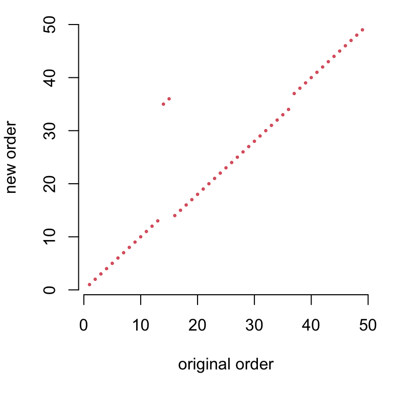

```
## [1] 4
##    nclust      AIC      BIC nIt
## n2      2 12615.94 14716.65 650
## n3      3 10206.56 13361.29 631
## n4      4 10247.33 14456.07 284
## n5      5 10321.42 15584.18 188
##    nclust      AIC      BIC nIt
## n2      2 13303.97 15414.01 421
## n3      3 10739.89 13912.27 632
## n4      4 10796.42 15031.15 299
## n5      5 10867.09 16164.16 173
##            cluster.bsc
## cluster.scs  1  2  3
##           1 15  0  0
##           2  0 41  0
##           3  0  0 22
```

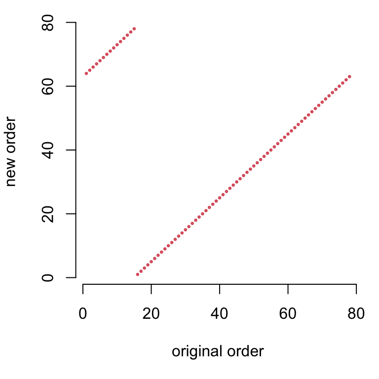

```
## [1] 5
##    nclust       AIC      BIC nIt
## n2      2 11952.983 13346.12 350
## n3      3  9642.664 11735.97 331
## n4      4  9394.643 12188.13 335
## n5      5  9377.873 12871.53 238
##    nclust      AIC      BIC nIt
## n2      2 12902.92 14305.29 379
## n3      3 10348.46 12459.23 330
## n4      4 10058.79 12877.97 252
## n5      5 10040.16 13567.75 217
##            cluster.bsc
## cluster.scs  1  2  3  4  5
##           1  8  0  0  0  0
##           2  0 17  0  0  0
##           3  0  0  6  2  0
##           4  0  0  3 35  0
##           5  0  0  0  0 34
```

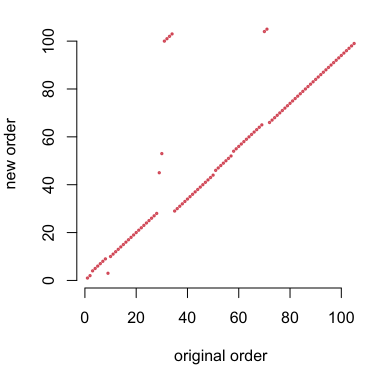

```r
mutB = gamma.plot.scs = gamma.plot.bsc = list()

for(i in 1:5){
  print(i)
  mutations = t(mutS[[i]])

  asrec  = trec = matrix(0, nrow=nrow(mutations), ncol=ncol(mutations))
  mutBki = mutBk[which(mutBk$Patient == paste("Patient", i)),]

  matchi = match(rownames(mutations), mutBki$loci)
  if(any(is.na(matchi))){ stop("some mutations were not found\n") }

  b.asrec = mutBki$altCount[matchi]
  b.trec  = mutBki$totalCount[matchi]
  b.cn    = rep(2, length(b.asrec))
  mutB[[i]] = cbind(b.asrec, b.trec)

  scs = cluster.SCS(mutations, asrec, trec, nclust=2:5, verbose=0)
  bsc = cluster.BSC(b.cn, b.asrec, b.trec, mutations, asrec, trec,
                    nclusters=2:5, verbose=0)

  print(scs$summary.cluster)
  print(bsc$summary.cluster)

  cluster.scs = apply(scs[[scs$nclust.by.AIC]]$postPs, 1, which.max)
  cluster.bsc = apply(bsc[[bsc$nclust.by.AIC]]$postPs, 1, which.max)

  print(table(cluster.scs, cluster.bsc))

  if(any(order(cluster.bsc) != 1:nrow(mutations))){
    mutations = mutations[order(cluster.bsc),]
    mutB[[i]] = mutB[[i]][order(cluster.bsc),]
    par(mar=c(5,4,1,1), bty="n")
    plot(1:nrow(mutations), order(cluster.bsc), xlab="original order",
         ylab="new order", pch=20, cex=0.5, col=rgb(0.8, 0.1, 0.1, 0.6))
  }

  gamma2plot = scs[[scs$nclust.by.AIC]]$gamma

  g0 = ggplot(melt(gamma2plot), aes(Var1, Var2, fill=value)) +
    geom_tile(aes(fill = value), color = "white", size=0.25) +
    scale_fill_gradient(low="white", high="red") +
    ylab("clusters") + xlab("cells") +
    scale_x_discrete(expand = c(0, 0)) +
    scale_y_discrete(expand = c(0, 0)) +
    theme(axis.text.x=element_blank(), legend.position = "none") +
    ggtitle('SCS only') + theme(plot.title = element_text(size = 10))

  gamma2plot = bsc[[bsc$nclust.by.AIC]]$gamma
  g1 = ggplot(melt(gamma2plot), aes(Var1, Var2, fill=value)) +
    geom_tile(aes(fill = value), color = "white", size=0.25) +
    scale_fill_gradient(low="white", high="red") +
    ylab("clusters") + xlab("cells") +
    scale_x_discrete(expand = c(0, 0)) +
    scale_y_discrete(expand = c(0, 0)) +
    theme(axis.text.x=element_blank(), legend.position = "none") +
    ggtitle('BaSiC') + theme(plot.title = element_text(size = 10))

  gamma.plot.scs[[i]] = g0
  gamma.plot.bsc[[i]] = g1

}
```

The following codes prepare the plots for SCS data as well as VAF from bulk tumor sequencing data.

```r
ga.plot = list()

for(i in 1:5){
  t2 = melt(mutS[[i]])
  names(t2)[1:2] = c("cell", "mutation")

  col2use = c("white", "darkred")

  g1 = ggplot(t2, aes(cell, mutation)) + theme_minimal() +
    geom_tile(aes(fill = as.factor(value)), color = "white", size=0.25) +
    ylab("mutations") + xlab("cells") + font("y.text", size = 6) +
    scale_fill_manual(values=col2use) +
    theme(axis.text.x=element_text(size=10), legend.position = "none")

  mutBi = mutB[[i]]
  df1 = data.frame(mutation=1:nrow(mutBi), VAF=mutBi[,1]/mutBi[,2])
  g2  = ggplot(data=df1, aes(x=mutation, y=VAF)) +
        scale_x_discrete(expand = c(0, 0)) +
        geom_bar(stat="identity", fill="steelblue") + theme_minimal()
  g2  = g2 + coord_flip()

  ga = ggarrange(g1, g2, ncol=2, align = "h", widths = c(2, 1))
  ga.plot[[i]] = ga
}
```

Finally we illustrate the data and estimation results.

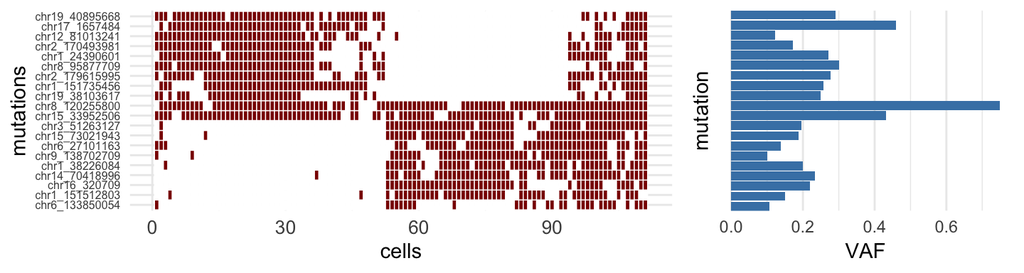

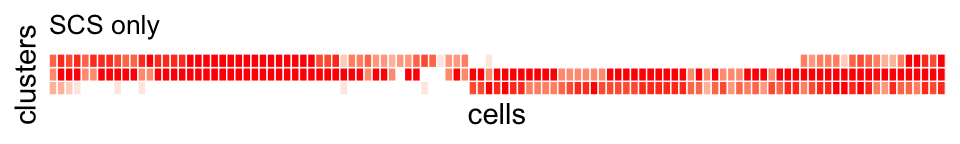

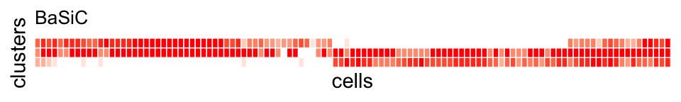

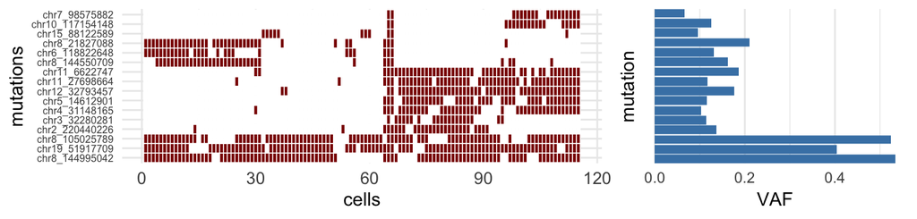

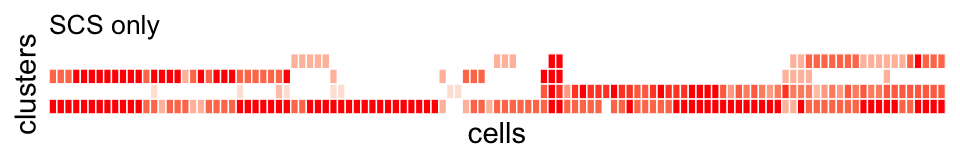

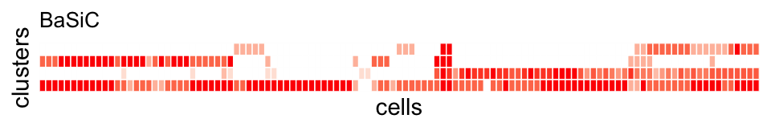

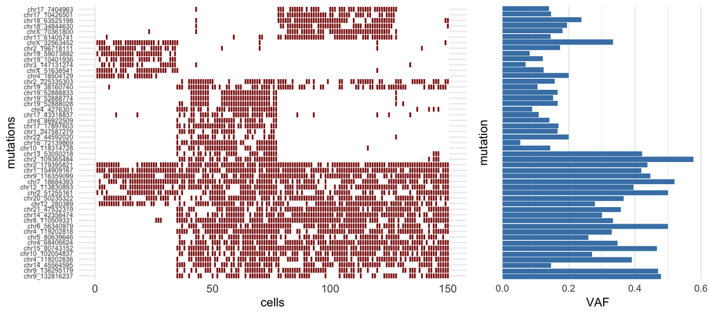

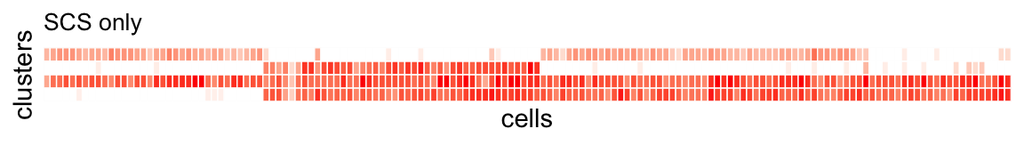

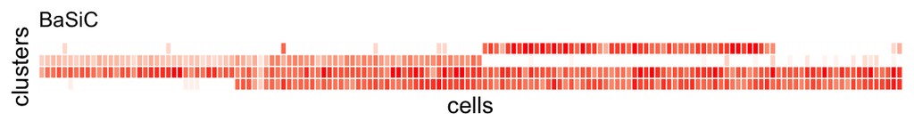

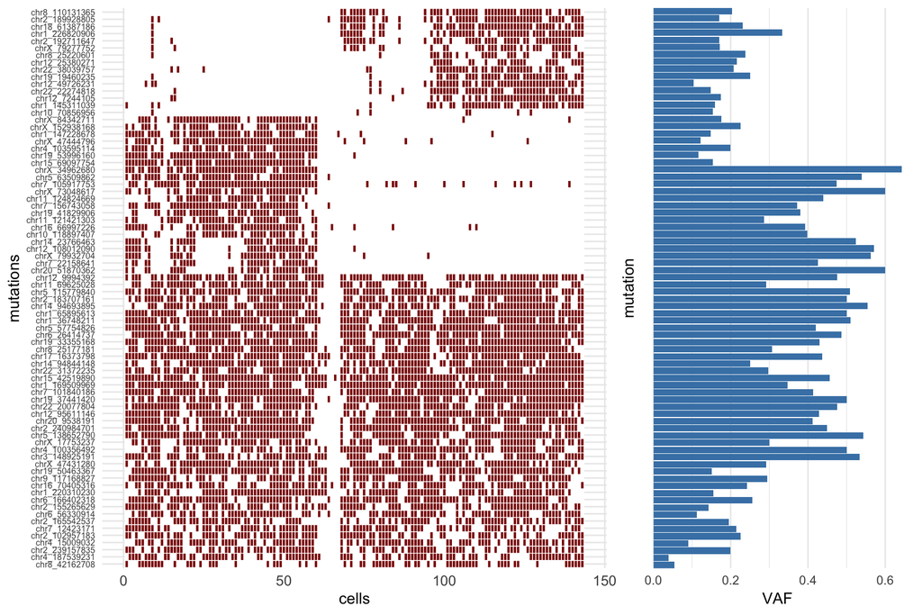

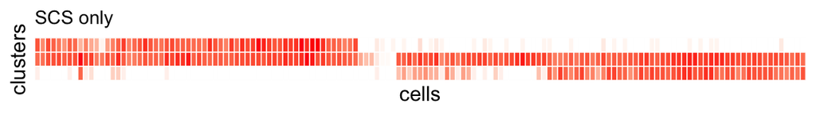

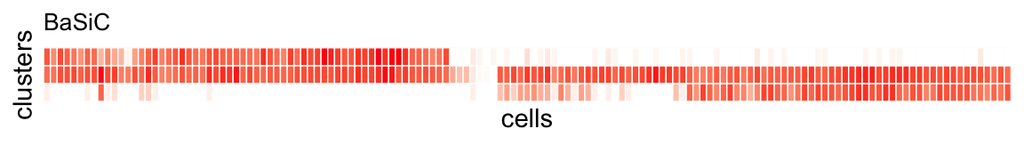

[3 more figures not shown]